# INT303 Big Data Analytics

## Lab 3 Data Visualization

**XJTLU**  
**S1 2021**  
**Instructors:** Jia WANG  
**Lab Instructor:** Jia WANG  
**Authors:** Rahul Dave, David Sondak, Will Claybaugh and Pavlos Protopaps

```python
## RUN THIS CELL TO PROPERLY HIGHLIGHT THE EXERCISES
import requests
```

# Visualization

In this lecture we focus on the visualization part of Exploratory Data Analysis. This notebook accompanies the slides. It is strongly recommended that you see the lecture/read the slides and then work on this notebook. The textual descriptions are sparse here and the code will become much clearer in the context of visualization best practices.

```python
# The %... is an iPython thing, and is not part of the Python language.
# In this case we're just telling the plotting library to draw things on
# the notebook, instead of on a separate window.
%matplotlib inline
#this line above prepares IPython notebook for working with matplotlib

# See all the "as ..." contructs? They're just aliasing the package names.
# That way we can call methods like plt.plot() instead of matplotlib.pyplot.plot().

import numpy as np # imports a fast numerical programming library
import scipy as sp #imports stats functions, amongst other things
import matplotlib as mpl # this actually imports matplotlib
import matplotlib.cm as cm #allows us easy access to colormaps
import matplotlib.pyplot as plt #sets up plotting under plt
import pandas as pd #lets us handle data as dataframes
#sets up pandas table display
pd.set_option('display.width', 500)
pd.set_option('display.max_columns', 100)
pd.set_option('display.notebook_repr_html', True)
```

```python
# versions below 0.8.1
import seaborn as sns #sets up styles and gives us more plotting options
```

## Getting the mtcars dataset into shape

The documentation for this data is [here](https://stat.ethz.ch/R-manual/R-devel/library/datasets/html/mtcars.html) but I have extracted some relevant parts below:

```
Description

The data was extracted from the 1974 Motor Trend US magazine, and comprises fuel consumption and 10 aspects of automobile design and performance for 32 automobiles (1973–74 models).

Usage

mtcars
Format

A data frame with 32 observations on 11 variables.

[, 1]	mpg	Miles/(US) gallon
[, 2]	cyl	Number of cylinders
[, 3]	disp	Displacement (cu.in.)
[, 4]	hp	Gross horsepower
[, 5]	drat	Rear axle ratio
[, 6]	wt	Weight (1000 lbs)
[, 7]	qsec	1/4 mile time
[, 8]	vs	V/S
[, 9]	am	Transmission (0 = automatic, 1 = manual)
[,10]	gear	Number of forward gears
[,11]	carb	Number of carburetors
Source

Henderson and Velleman (1981), Building multiple regression models interactively. Biometrics, 37, 391–411.

https://rstudio-pubs-static.s3.amazonaws.com/61800_faea93548c6b49cc91cd0c5ef5059894.html
```

```python
dfcars=pd.read_csv("./data/mtcars.csv")
dfcars.head()
```

|  | Unnamed: 0 | mpg | cyl | disp | hp | drat | wt | qsec | vs | am | gear | carb |
| --- | --- | --- | --- | --- | --- | --- | --- | --- | --- | --- | --- | --- |
| 0 | Mazda RX4 | 21.0 | 6 | 160.0 | 110 | 3.90 | 2.620 | 16.46 | 0 | 1 | 4 | 4 |
| 1 | Mazda RX4 Wag | 21.0 | 6 | 160.0 | 110 | 3.90 | 2.875 | 17.02 | 0 | 1 | 4 | 4 |
| 2 | Datsun 710 | 22.8 | 4 | 108.0 | 93 | 3.85 | 2.320 | 18.61 | 1 | 1 | 4 | 1 |
| 3 | Hornet 4 Drive | 21.4 | 6 | 258.0 | 110 | 3.08 | 3.215 | 19.44 | 1 | 0 | 3 | 1 |
| 4 | Hornet Sportabout | 18.7 | 8 | 360.0 | 175 | 3.15 | 3.440 | 17.02 | 0 | 0 | 3 | 2 |

There is an ugly poorly named column right here. Lets fix that.

```python
dfcars=dfcars.rename(columns={"Unnamed: 0":"name"})
dfcars.head()
```

|  | name | mpg | cyl | disp | hp | drat | wt | qsec | vs | am | gear | carb |
| --- | --- | --- | --- | --- | --- | --- | --- | --- | --- | --- | --- | --- |
| 0 | Mazda RX4 | 21.0 | 6 | 160.0 | 110 | 3.90 | 2.620 | 16.46 | 0 | 1 | 4 | 4 |
| 1 | Mazda RX4 Wag | 21.0 | 6 | 160.0 | 110 | 3.90 | 2.875 | 17.02 | 0 | 1 | 4 | 4 |
| 2 | Datsun 710 | 22.8 | 4 | 108.0 | 93 | 3.85 | 2.320 | 18.61 | 1 | 1 | 4 | 1 |
| 3 | Hornet 4 Drive | 21.4 | 6 | 258.0 | 110 | 3.08 | 3.215 | 19.44 | 1 | 0 | 3 | 1 |
| 4 | Hornet Sportabout | 18.7 | 8 | 360.0 | 175 | 3.15 | 3.440 | 17.02 | 0 | 0 | 3 | 2 |

```python
dfcars.shape
```

[output not shown]

We parse out a `maker`, which we shall lkater use to group cars.

```python
dfcars['maker'] = dfcars.name.apply(lambda x: x.split()[0])
dfcars['maker']
```

```
0        Mazda
1        Mazda
2       Datsun
3       Hornet
4       Hornet
5      Valiant
6       Duster
7         Merc
8         Merc
9         Merc
10        Merc
11        Merc
12        Merc
13        Merc
14    Cadillac
```

[output cut: 18 more lines]

This is what the dataframe looks like now:

```python
dfcars.head()
```

|  | name | mpg | cyl | disp | hp | drat | wt | qsec | vs | am | gear | carb | maker |
| --- | --- | --- | --- | --- | --- | --- | --- | --- | --- | --- | --- | --- | --- |
| 0 | Mazda RX4 | 21.0 | 6 | 160.0 | 110 | 3.90 | 2.620 | 16.46 | 0 | 1 | 4 | 4 | Mazda |
| 1 | Mazda RX4 Wag | 21.0 | 6 | 160.0 | 110 | 3.90 | 2.875 | 17.02 | 0 | 1 | 4 | 4 | Mazda |
| 2 | Datsun 710 | 22.8 | 4 | 108.0 | 93 | 3.85 | 2.320 | 18.61 | 1 | 1 | 4 | 1 | Datsun |
| 3 | Hornet 4 Drive | 21.4 | 6 | 258.0 | 110 | 3.08 | 3.215 | 19.44 | 1 | 0 | 3 | 1 | Hornet |
| 4 | Hornet Sportabout | 18.7 | 8 | 360.0 | 175 | 3.15 | 3.440 | 17.02 | 0 | 0 | 3 | 2 | Hornet |

We can construct the `av_mpg` series by using the "split-apply-combine" paradigm and summarizing within group data by a mean:

```python
av_mpg = dfcars.groupby('maker').mpg.mean()
```

```python
sns.set_context("notebook")
```

```python
sns.color_palette()
```

```
[(0.12156862745098039, 0.4666666666666667, 0.7058823529411765),
 (1.0, 0.4980392156862745, 0.054901960784313725),
 (0.17254901960784313, 0.6274509803921569, 0.17254901960784313),
 (0.8392156862745098, 0.15294117647058825, 0.1568627450980392),
 (0.5803921568627451, 0.403921568627451, 0.7411764705882353),
 (0.5490196078431373, 0.33725490196078434, 0.29411764705882354),
 (0.8901960784313725, 0.4666666666666667, 0.7607843137254902),
 (0.4980392156862745, 0.4980392156862745, 0.4980392156862745),
 (0.7372549019607844, 0.7411764705882353, 0.13333333333333333),
 (0.09019607843137255, 0.7450980392156863, 0.8117647058823529)]
```

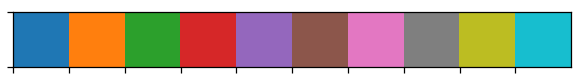

```python
sns.palplot(sns.color_palette());
```

We can choose other palettes. The default palette is for qualitative data. It creates a color cycle we use in our plots. In other words, as we plot multiple things in a plot, it will use these colors one-by-one.

#### Bar Charts

We see that Pandas series very niftily give us bar graphs.

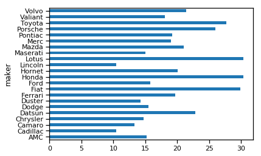

```python
av_mpg.plot(kind="barh")
```

```python
sns.reset_defaults()
```

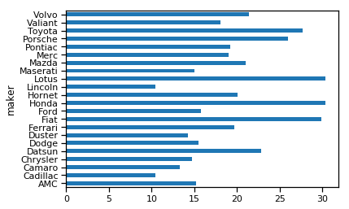

```python
av_mpg.plot(kind="barh")
```

The default, which comes from matplotlib, is chart-junky (although not as much as matlab, or as much as it used to be in earlier versions of matplotlib). But lets clean it.

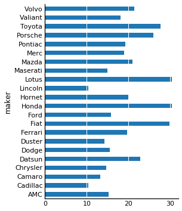

```python
plt.figure(figsize=(4, 6))
ax = plt.gca()
av_mpg.plot(kind="barh")
plt.grid(axis = 'x', color ='white', linestyle='-')
ax.tick_params(axis='both', which='both',length=0)
sns.despine() #
```

And more....

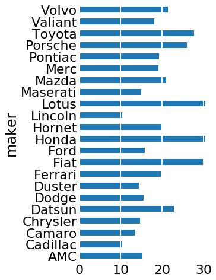

```python
plt.figure(figsize=(4, 8))

with sns.plotting_context("poster"):
    ax = plt.gca()
    av_mpg.plot(kind="barh")
    plt.grid(axis = 'x', color ='white', linestyle='-')
    ax.tick_params(axis='both', which='both',length=0)
    sns.despine(left=True, bottom=True)
```

Its important to understand what is going on under the hood. Try and write `sns.despine` on your own by looking up the matplotlib documentation.

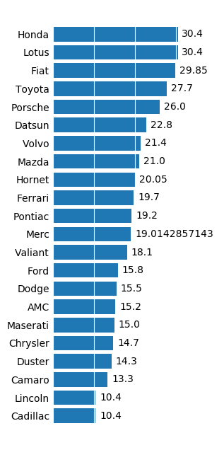

```python
plt.figure(figsize=(3, 8))
ax = plt.gca()
av_mpg2 = av_mpg.sort_values()
makes = av_mpg2.index
speeds = av_mpg2.values
nums = np.arange(len(av_mpg2))
plt.barh(nums, speeds)
for p, c, ch in zip(nums, makes, speeds):
    plt.annotate(str(ch), xy=(ch + 1, p), va='center')
ticks = plt.yticks(nums, makes)
xt = plt.xticks()[0]
plt.xticks(xt, [' '] * len(xt))
plt.grid(axis = 'x', color ='white', linestyle='-')
ax.tick_params(axis='both', which='both',length=0)
sns.despine(left=True, bottom=True)
```

#### Histograms

Numerical data leads to distributions, and distributions to histograms. Here is the Pandas default

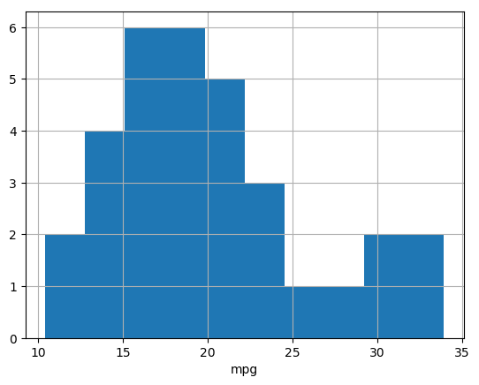

```python
dfcars.mpg.hist()
plt.xlabel("mpg");
```

And matplotlib:

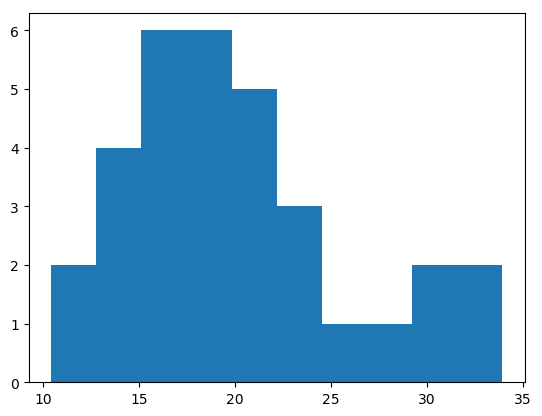

```python
plt.hist(dfcars.mpg.values);
```

Lets style it a bit with seaborn. The `with` syntax followed by indentation is a python construct called a "context manager". Here it sets up a while axes style only for the code that is *inside* the context (ie, indented).

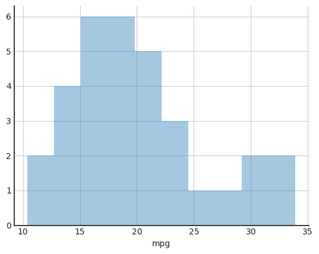

```python
with sns.axes_style("white"):
    dfcars.mpg.hist(alpha=0.4)
    plt.xlabel("mpg");
    sns.despine()
```

What if I wanted to get the benefit of the default seaborn style and colors?

```python
sns.set()
```

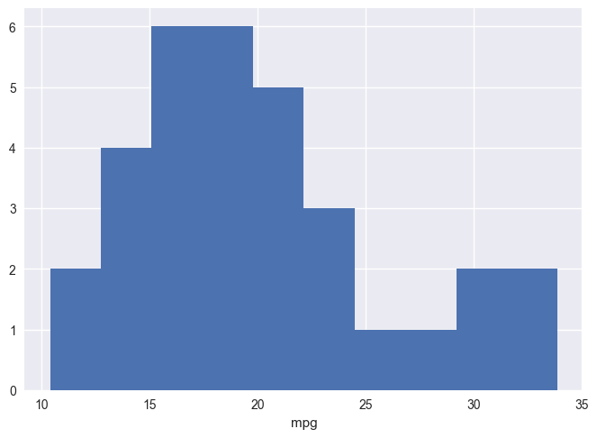

```python
dfcars.mpg.hist()
plt.xlabel("mpg");
sns.despine()
```

I can `reset_defaults` back to the matplotlib defaults.

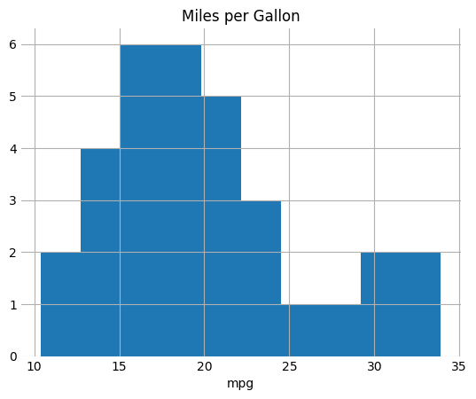

```python
sns.reset_defaults()
ax = plt.gca()
dfcars.mpg.hist()
plt.xlabel("mpg");
plt.title("Miles per Gallon")
ax.tick_params(axis='both', which='both',length=0)
sns.despine(bottom=True, left=True)
```

Here are the most commonly used matplotlib plotting routines.

[figure not shown]

Here we use a white grid. We also illustrate how a series can be converted to a numpy array with the `values` method (`dfcars.mpg.values`) and how x and y limits can be set (the difference in the way `xlim` and `ylim` are called is on purpose and illustrates two ways you can set the limits). In the `hist` function you can also change the number of bins. We also show how to label a plot and obtain a legend from the plot. A vertical line is drawn at the mean.

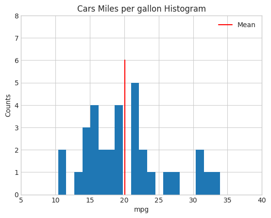

```python
with sns.axes_style("whitegrid"):
    plt.hist(dfcars.mpg.values, bins=20)
    plt.xlim(5, 40)
    plt.ylim([0, 8])
    plt.axvline(dfcars.mpg.mean(), 0, 0.75, color='r', label='Mean')
    plt.xlabel("mpg")
    plt.ylabel("Counts")
    plt.title("Cars Miles per gallon Histogram")
    plt.legend()
```

One can set bins using a list, and also label the histogram (not recommended but just for illustration). We also illustrate how to capture the color used and use it again

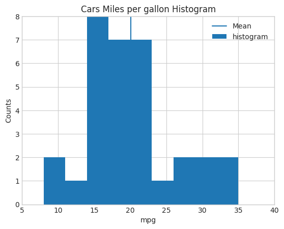

```python
with sns.axes_style("whitegrid"):
    color = sns.color_palette()[0]
    plt.hist(dfcars.mpg.values, bins=range(5, 40, 3), label="histogram", color=color)
    plt.xlim(5, 40)
    plt.ylim([0, 8])
    plt.axvline(dfcars.mpg.mean(), 0, 1.0, color=color, label='Mean')
    plt.xlabel("mpg")
    plt.ylabel("Counts")
    plt.title("Cars Miles per gallon Histogram")
    plt.legend()
```

Seaborn very handily provides Kernel Density Estimates (KDE) which try to infer a probability distribution from the data. This is more useful when you have lots of data.

```python
sns.set()
```

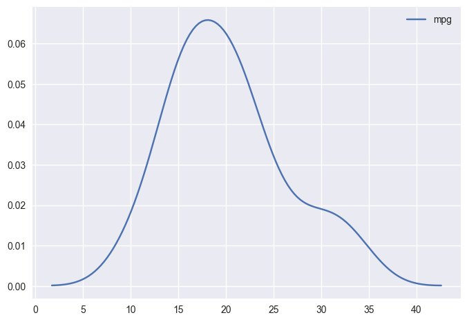

```python
sns.kdeplot(dfcars.mpg);
```

And a histogram and a kdeplot together:

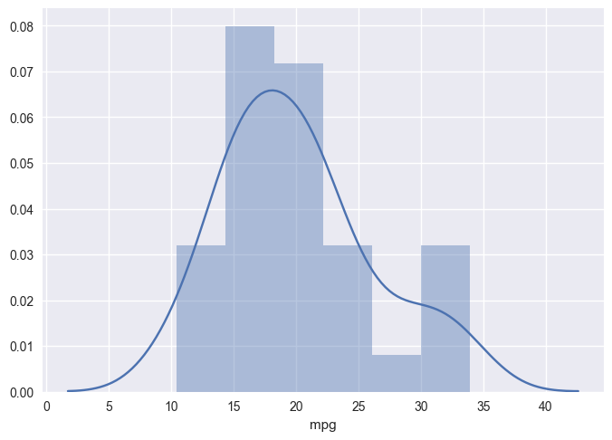

```python
sns.distplot(dfcars.mpg);
```

### Plotting features against other features

Sometimes we want to see co-variation amongst our columns. A scatter-plot does this for us.

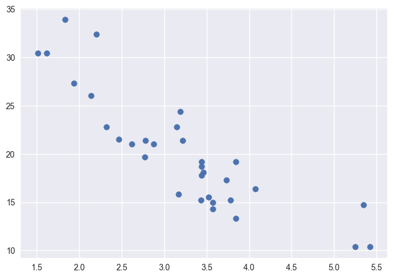

```python
plt.scatter(dfcars.wt, dfcars.mpg);
```

We can also use `plot` without lines:

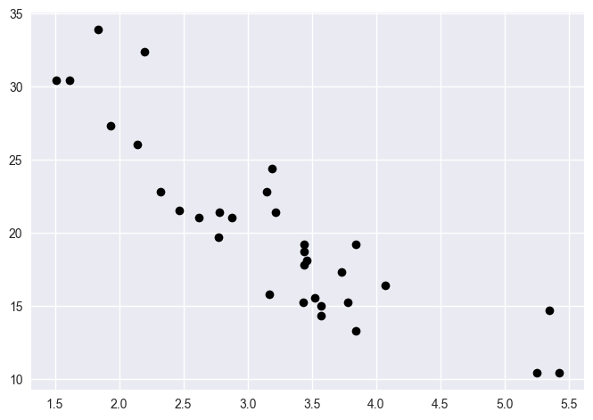

```python
plt.plot(dfcars.wt, dfcars.mpg, marker='o', linestyle='None', color='k');
```

Usually we use `plt.show()` at the end of every plot to show the plot. Out magic incantation `%matplotlib inline` takes care of this for us, and we dont have to doit in the jupyter notebook. But if you run your puthon program from a file, you will need to explicitly have a call to show. Does not hurt us to include it...

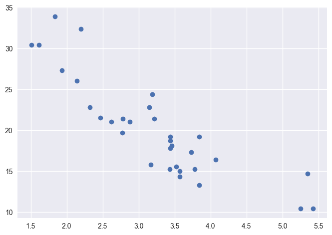

```python
plt.plot(dfcars.wt, dfcars.mpg, 'o')
plt.show()
```

But what if we want to save our figure into a file? The extension tells you how it will be saved..and note that the `savefig` needs to be in the same cell as the plotting commands. Go look at the files..

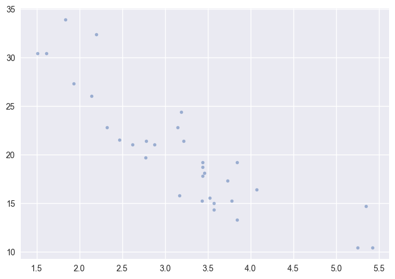

```python
plt.plot(dfcars.wt, dfcars.mpg, 'o', markersize=4, alpha=0.5)
plt.savefig('foo1.pdf')
plt.savefig('foo2.png', bbox_inches='tight') #less whitespace around image
```

#### Trend

The correlation that we saw might suggest a trend. We can capture it with a "regression". We'll learn more about regressions soon, but we show a quadratic fit here with a 1 standard deviation bar to show the graphics aspect of this. Also see `sns.regplot`.

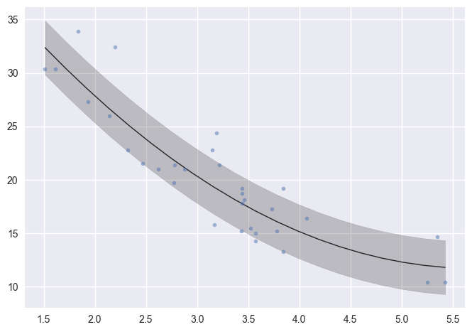

```python
x = dfcars.wt
y = dfcars.mpg
params = np.polyfit(x, y, 2)
xp = np.linspace(x.min(), x.max(), 20)
yp = np.polyval(params, xp)
plt.plot(xp, yp, 'k', alpha=0.8, linewidth=1)
plt.plot(dfcars.wt, dfcars.mpg, 'o', markersize=4, alpha=0.5)
sig = np.std(y - np.polyval(params, x))
plt.fill_between(xp, yp - sig, yp + sig,
                 color='k', alpha=0.2)
```

```
          7             6             5             4            3
5.37e-18 x - 1.982e-14 x + 2.897e-11 x - 2.126e-08 x + 8.17e-06 x
             2
 - 0.001545 x + 0.1155 x - 1.403
```

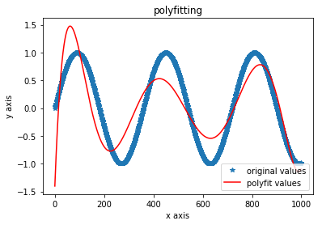

```python
import numpy as np
import matplotlib.pyplot as plt

xxx = np.arange(0, 1000)  # x值，此时表示弧度
yyy = np.sin(xxx*np.pi/180)  #函数值，转化成度
z1 = np.polyfit(xxx, yyy, 7) # 用7次多项式拟合，可改变多项式阶数；
p1 = np.poly1d(z1) #得到多项式系数，按照阶数从高到低排列
print(p1)  #显示多项式

yvals=p1(xxx) # 可直接使用yvals=np.polyval(z1,xxx)
plt.plot(xxx, yyy, '*',label='original values')
plt.plot(xxx, yvals, 'r',label='polyfit values')
plt.xlabel('x axis')
plt.ylabel('y axis')
plt.legend(loc=4) # 指定legend在图中的位置，类似象限的位置
plt.title('polyfitting')

plt.show()
```

## Group Properties

Such "co-variational" plots, and for that matter, even single-variable plots, are even more interesting when we look at them **conditional** upon the value of a categorical variable.

Such conditionality is behind the notion of grouping, where we group our data by various values of categorical variables, for example, whether our cars have an automatic transmission or not.

### Grouping of one outcome variable

This notion of grouping based on combinations of factors is used by seaborn to make various easy-to-see exploratory visualizations for us. We shall first see how to make these plots quick-and-dirty using `seaborn` and then see how we make make these plots ourselves.

First, we make a boxplot of `mpg`, grouped by transmission style

https://towardsdatascience.com/understanding-boxplots-5e2df7bcbd51

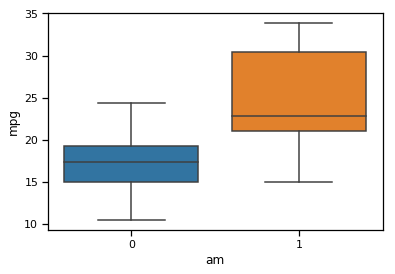

```python
sns.boxplot(x='am', y='mpg', data=dfcars);
```

The box shows the quartiles of the distribution This can also be done using a violin-plot, which uses KDE to show the distribution itself: https://towardsdatascience.com/violin-plots-explained-fb1d115e023d

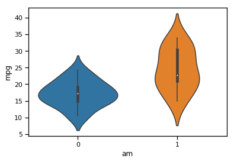

```python
sns.violinplot(x='am', y='mpg', data=dfcars);
```

Split violin plots can be used to do multiple categorical variables

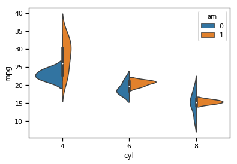

```python
sns.violinplot(x='cyl', y='mpg', hue='am', order=[4, 6, 8], data=dfcars, split=True);
```

```python
pd.crosstab(dfcars.am, dfcars.cyl)
```

| cyl am | 4 | 6 | 8 |
| --- | --- | --- | --- |
| 0 | 3 | 4 | 12 |
| 1 | 8 | 3 | 2 |

### Faceting for general grouping

Seaborn provides a nice construct: the `FacetGrid`. You decide what variables to facet over, and then decide the kind of plot you want. Here we want hue to be `am`, and different columns in the plot grid to be cylinders. We then ask for a facet plot of `mpg` against `wt` scatter.

Such plots are often called small multiple plots. They repeat the same plot based on categories, making sure that all plotting parameters are the same so that we have direct comparability.

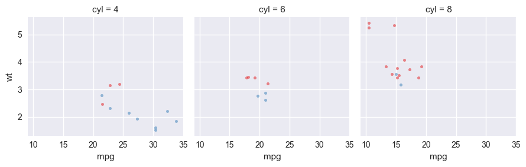

```python
g = sns.FacetGrid(dfcars, col="cyl", hue="am", palette="Set1")
g.map(plt.scatter, "mpg", "wt", alpha=0.5, s=10);
```

#### SPLOM, or Scatter Plot Matrix

We'd get tired if we had to this on a 2-by-2 basis for every pair of continuously co-varying features. The `PairGrid`, colorable by transmission type, allows us to do this comparison for 5 continuous features here, with the diagonal being a kernel density estimate.

```python
dfcars_short=dfcars[["mpg", "cyl","disp"]]
dfcars_short.head(10)
```

|  | mpg | cyl | disp |
| --- | --- | --- | --- |
| 0 | 21.0 | 6 | 160.0 |
| 1 | 21.0 | 6 | 160.0 |
| 2 | 22.8 | 4 | 108.0 |
| 3 | 21.4 | 6 | 258.0 |
| 4 | 18.7 | 8 | 360.0 |
| 5 | 18.1 | 6 | 225.0 |
| 6 | 14.3 | 8 | 360.0 |
| 7 | 24.4 | 4 | 146.7 |
| 8 | 22.8 | 4 | 140.8 |
| 9 | 19.2 | 6 | 167.6 |

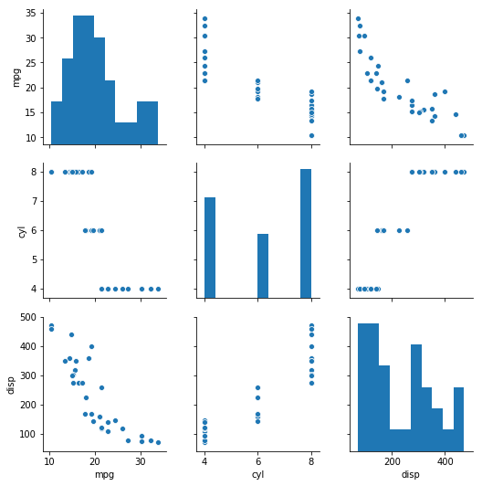

```python
sns.pairplot(dfcars_short, size=2.5)
```

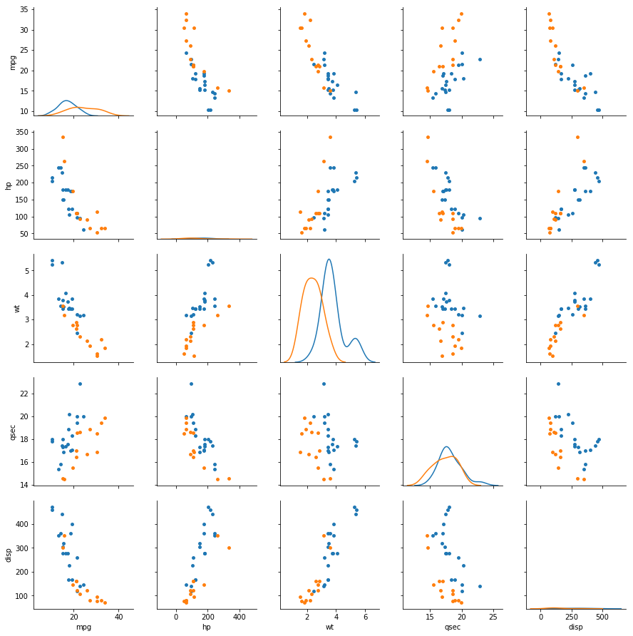

```python
g = sns.PairGrid(dfcars, vars=['mpg', 'hp', 'wt', 'qsec', 'disp'], hue="am")
g.map_diag(sns.kdeplot)
g.map_offdiag(plt.scatter, s=15)
```

In many places, for example `mpg` vs `disp`, there see to be two separate trends for the different transmissions. This will (as we shall see later in this course) suggest to us the addition of a transmission term as a **indicator** variable in regressions for `mpg` against various features. This changes the intercept of the regression. But the trends have different slopes as well, which suggests that `disp` may interact with `am`, the transmission indicator to create a varying slope as well.

#### Correlation

The SPLOM seems to suggest correlations. Well, so lets calculate it:

```python
dfcars[['mpg', 'wt', 'hp', 'qsec', 'disp']].corr()
```

|  | mpg | wt | hp | qsec | disp |
| --- | --- | --- | --- | --- | --- |
| mpg | 1.000000 | -0.867659 | -0.776168 | 0.418684 | -0.847551 |
| wt | -0.867659 | 1.000000 | 0.658748 | -0.174716 | 0.887980 |
| hp | -0.776168 | 0.658748 | 1.000000 | -0.708223 | 0.790949 |
| qsec | 0.418684 | -0.174716 | -0.708223 | 1.000000 | -0.433698 |
| disp | -0.847551 | 0.887980 | 0.790949 | -0.433698 | 1.000000 |

Since correlations range from -1 to 1 through 0, a diverging palette is probably our best bet.

We use `maptplotlib`s correlation plot. You'll land up doing plots like this for both EDA and do see misclassification from your machine learning algorithms. In other words, EDA is even useful at the analysis stage.

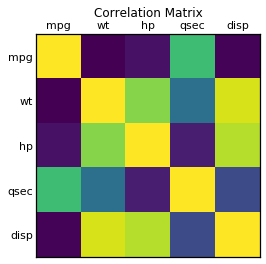

```python
plt.matshow(dfcars[['mpg', 'wt', 'hp', 'qsec', 'disp']].corr())
ax = plt.gca() # get the current axies
ax.tick_params(axis='both', which='both',length=0);
plt.title("Correlation Matrix")
plt.xticks(range(5), ['mpg', 'wt', 'hp', 'qsec', 'disp'])
plt.yticks(range(5), ['mpg', 'wt', 'hp', 'qsec', 'disp']);
```

### KDE plots and sequential palettes.

Here we make a KDE plot of a multivariate normal distribution. Since a probability density is strictly positive, with values near 0 not being so interesting, a sequential palette is our ticket. Seaborn will by default provide such a palette for KDE plots, but you can use your own!

```python
mean, cov = [0, 1], [(1, .5), (.5, 1)]
data = np.random.multivariate_normal(mean, cov, 1000)
df = pd.DataFrame(data, columns=["x", "y"])
df.head()
```

|  | x | y |
| --- | --- | --- |
| 0 | -0.227001 | -0.070635 |
| 1 | 1.288382 | 2.753928 |
| 2 | -0.388508 | 1.017118 |
| 3 | 1.085857 | 2.465086 |
| 4 | 0.034475 | 1.274053 |

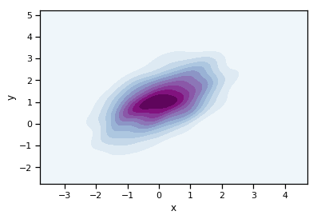

```python
sns.kdeplot(df.x, df.y, cmap='BuPu', shade=True);
```

## Matplotlib and multiple plots: Small Multiples

There are many cases where we want to see plots side by side. The SPLOMS and Facet grids that seaborn makes for us are an example.But we should know how to do this on our own.

[figure not shown]

Here is a simple example of a plot with one column and 3 rows. It illustrates one way of doing this.

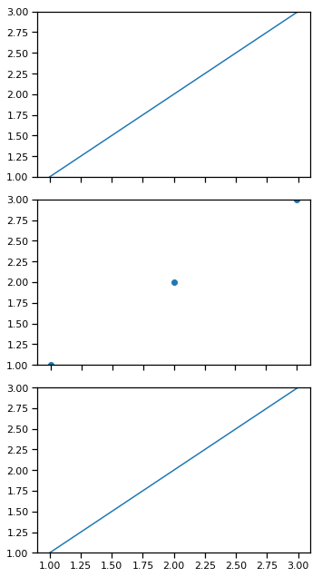

```python
fig = plt.figure(figsize=(5, 9))

ax1 = fig.add_subplot(311)
ax1.plot([1, 2, 3], [1, 2, 3])
ax1.set_xticklabels([])
ax1.set_ylim([1.0, 3.0])

ax2 = fig.add_subplot(312)
ax2.scatter([1, 2, 3], [1, 2, 3])
ax2.set_xticklabels([])
ax2.set_ylim([1.0, 3.0])

ax3 = fig.add_subplot(313)
ax3.plot([1, 2, 3], [1, 2, 3])
ax3.set_ylim([1.0, 3.0])


fig.tight_layout()
```

### Small multiples, youself

Here is another way, which to me is far clearer that the `add_subplot` way. It basically creates an array of plots and zips this array up with the various data grouped by categories.

```
(7, 13)
(10, 13)
(3, 13)
(12, 13)
```

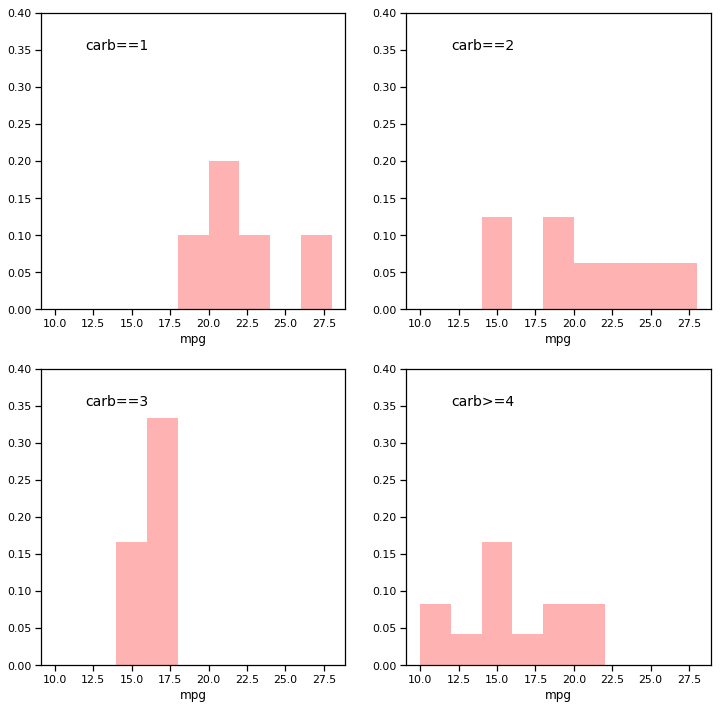

```python
fig, axes = plt.subplots(nrows=2, ncols=2, figsize=(12, 12))
print(axes)
print(axes.ravel())
carbs = ['==1', '==2', '==3', '>=4']
bins = np.arange(10, 30, 2)
for ax, carb in zip(axes.ravel(), carbs):
    data = dfcars.query("carb%s" % carb)
    print(data.shape)
    #ax.plot(data.wt, data.mpg, 'o', markersize=10, alpha=0.5)
    ax.hist(data.mpg, bins=bins, histtype='stepfilled', normed=True, color='r', alpha=.3)
    ax.annotate("carb"+str(carb), xy=(12, 0.35), fontsize=14)
    #ax.set_yticks([])
    ax.set_ylim((0,0.4))
    ax.set_xlabel('mpg');
```